# R Notebook

13E3. Rewrite the following model as a multilevel model.

yi~Normal(mui, sigma)

mui=alphagroup[i] + beta*xi

alphagroup[i]~Normal(0,5)

beta~Normal(0,1)

sigma~Exponential(1)

**Solution:**

**y<sub>i</sub> ∼Normal(µ<sub>i</sub>, σ)**

**µ<sub>i</sub> = αgroup[i] + β<sub>xi</sub>**

**α<sub>group</sub> ∼Normal(α, σ<sub>α</sub>)**

**β∼Normal(0, 1)**

**σ ∼Exponential(0, 1)**

**α ∼Normal(0, 5)**

**σ<sub>α</sub> ∼Exponential(0, 1)**

**The key point is that in the original model, αgroup has only a prior distribution. In the multilevel version, αgroup has a distribution with higher level or hyperparameters. We can learn about these hyperparameters from the data in the second version as opposed to having to set them apriori in the original model.**

13M1. Revisit the Reed frog survival data, data(reedfrogs), and add the predation and size treatment variables to the varying intercepts model. Consider models with either main effect alone, both main effects, as well as a model including both and their interaction. Instead of focusing on inferences about these two predictor variables, focus on the inferred variation across tanks. Explain why it changes as it does across models.

**First, let’s set up the data list:**

```r
library(rethinking)
data(reedfrogs)
d <- reedfrogs
dat <- list(
S = d$surv,
n = d$density,
tank = 1:nrow(d),
pred = ifelse( d$pred=="no" , 0L , 1L ),
size_ = ifelse( d$size=="small" , 1L , 2L )
)
```

**Now to define a series of models. The first is just the varying intercepts model from the text:**

```r
m1.1 <- ulam(
alist(
S ~ binomial( n , p ),
logit(p) <- a[tank],
a[tank] ~ normal( a_bar , sigma ),
a_bar ~ normal( 0 , 1.5 ),
sigma ~ exponential( 1 )
), data=dat , chains=4 , cores=4 , log_lik=TRUE )
```

[output not shown]

**The other models just incorporate the predictors, as ordinary regression terms.**

```r
# pred
m1.2 <- ulam(
alist(
S ~ binomial( n , p ),
logit(p) <- a[tank] + bp*pred,
a[tank] ~ normal( a_bar , sigma ),
bp ~ normal( -0.5 , 1 ),
a_bar ~ normal( 0 , 1.5 ),
sigma ~ exponential( 1 )
), data=dat , chains=4 , cores=4 , log_lik=TRUE )
```

[output not shown]

```r
# size
m1.3 <- ulam(
alist(
S ~ binomial( n , p ),
logit(p) <- a[tank] + s[size_],
a[tank] ~ normal( a_bar , sigma ),
s[size_] ~ normal( 0 , 0.5 ),
a_bar ~ normal( 0 , 1.5 ),
sigma ~ exponential( 1 )
), data=dat , chains=4 , cores=4 , log_lik=TRUE )
```

[output not shown]

[output not shown]

[output not shown]

[output not shown]

[output not shown]

```
## Chain 2
```

[output not shown]

```r
# pred + size
m1.4 <- ulam(
alist(
S ~ binomial( n , p ),
logit(p) <- a[tank] + bp*pred + s[size_],
a[tank] ~ normal( a_bar , sigma ),
bp ~ normal( -0.5 , 1 ),
s[size_] ~ normal( 0 , 0.5 ),
a_bar ~ normal( 0 , 1.5 ),
sigma ~ exponential( 1 )
), data=dat , chains=4 , cores=4 , log_lik=TRUE )
```

[output not shown]

[output not shown]

[output not shown]

[output not shown]

[output not shown]

```
## Chain 4
```

[output not shown]

```r
# pred + size + interaction
m1.5 <- ulam(
alist(
S ~ binomial( n , p ),
logit(p) <- a_bar + z[tank]*sigma + bp[size_]*pred + s[size_],
z[tank] ~ normal( 0 , 1 ),
bp[size_] ~ normal( -0.5 , 1 ),
s[size_] ~ normal( 0 , 0.5 ),
a_bar ~ normal( 0 , 1.5 ),
sigma ~ exponential( 1 )
), data=dat , chains=4 , cores=4 , log_lik=TRUE )
```

[output not shown]

**I coded the interaction model using a non-centered parameterization. The interaction itself is done by creating a bp parameter for each size value. In this way, the effect of pred depends upon size. Let’s look at all the sigma posterior distributions:**

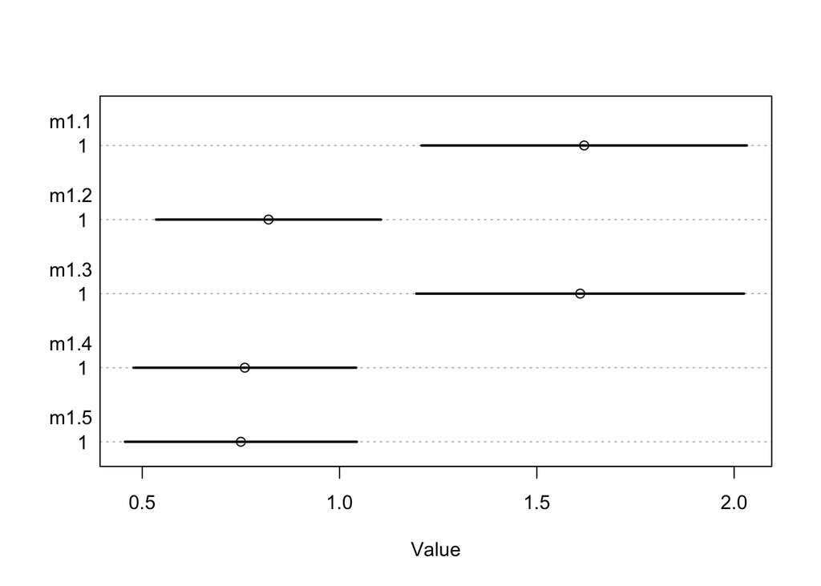

```r
plot( coeftab( m1.1 , m1.2 , m1.3 , m1.4 , m1.5 ), pars="sigma" )
```

**The two models that omit predation, m1.1 and m1.3, have larger values of sigma. This is because predation explains some of the variation among tanks. So when you add it to the model, the variation in the tank intercepts gets smaller.**

**The general point is that the model with only intercepts measures the variation among tanks, but does nothing to explain it. As we add treatment variables, the variation should shrink, even though the total variation in the data of course stays the same.**